# Growth Curve Analysis, Part 4

Dan Mirman

28 November 2019

# Contrast coding

For categorical predictor variables, the default in `R` is to use *treatment* coding: the reference (first) level is set as the baseline (0) and parameters for the other levels (1) are estimated.

This is fine in many cases, but can be confusing when you have multiple categorical predictors because treatment coding produces *simple* effect estimates rather than *main* effect estimates.

Example: `MotorLearning` - effects of task difficulty and impairment (alcohol) on motor learning.

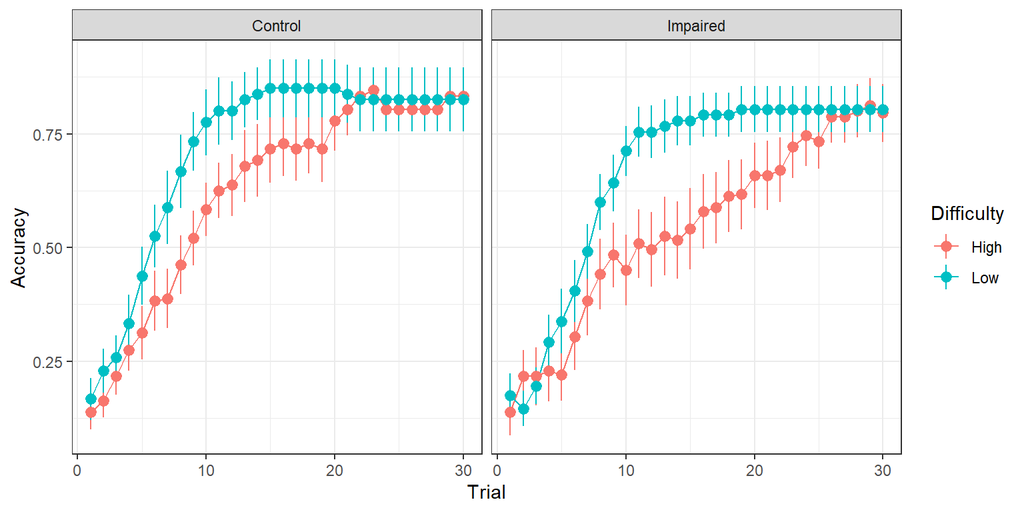

```r
ggplot(MotorLearning, aes(Trial, Accuracy, color=Difficulty)) +
  facet_wrap(~ Condition) + stat_summary(fun.y=mean, geom="line") +
  stat_summary(fun.data=mean_se, geom="pointrange") + theme_bw()
```

# Motor Learning: fit GCA model

```r
# prep data for GCA
MotorLearning.gca <- code_poly(df=MotorLearning, predictor="Trial", poly.order=3, draw.poly=FALSE)
# fit full model
m.ML <- lmer(Accuracy ~ (poly1+poly2+poly3)*Difficulty*Condition +
               (poly1+poly2+poly3 | SubjID) +
               (poly1+poly2+poly3 | SubjID:Difficulty:Condition),
             data=MotorLearning.gca, REML=F)
# coefficients and p-values
get_pvalues(m.ML)[1:9, ]
```

```
##                     Estimate Std..Error t.value  p.normal p.normal.star
## (Intercept)          0.62111    0.04572 13.5865 0.000e+00           ***
## poly1                1.10820    0.13495  8.2120 2.220e-16           ***
## poly2               -0.44104    0.08602 -5.1273 2.939e-07           ***
## poly3                0.04990    0.06875  0.7258 4.680e-01
## DifficultyLow        0.09014    0.05123  1.7594 7.851e-02             .
## ConditionImpaired   -0.07986    0.05123 -1.5588 1.190e-01
## poly1:DifficultyLow -0.22495    0.16530 -1.3608 1.736e-01
## poly2:DifficultyLow -0.22908    0.10889 -2.1038 3.539e-02             *
## poly3:DifficultyLow  0.18467    0.08510  2.1700 3.001e-02             *
```

`DifficultyLow` parameter is not significant, which seems strange because there is a very consistent task difficulty effect.

This parameter is just for the *simple* effect of Difficulty in the Control condition. Not the main effect Difficulty across both conditions.

# Motor Learning: re-fit GCA model

```r
m.ML_sum <- lmer(Accuracy ~ (poly1+poly2+poly3)*Difficulty*Condition +
                   (poly1+poly2+poly3 | SubjID) +
                   (poly1+poly2+poly3 | SubjID:Difficulty:Condition),
               contrasts = list(Condition = "contr.sum"),
               data=MotorLearning.gca, REML=F)
# coefficients and p-values
get_pvalues(m.ML_sum)[1:9, ]
```

```
##                     Estimate Std..Error t.value  p.normal p.normal.star
## (Intercept)          0.58118    0.03794 15.3202 0.000e+00           ***
## poly1                1.08472    0.10705 10.1326 0.000e+00           ***
## poly2               -0.29988    0.06673 -4.4937 7.001e-06           ***
## poly3                0.05346    0.05424  0.9857 3.243e-01
## DifficultyLow        0.10535    0.03622  2.9086 3.630e-03            **
## Condition1           0.03993    0.02561  1.5591 1.190e-01
## poly1:DifficultyLow -0.15326    0.11725 -1.3070 1.912e-01
## poly2:DifficultyLow -0.34688    0.07703 -4.5031 6.696e-06           ***
## poly3:DifficultyLow  0.15038    0.06014  2.5005 1.240e-02             *
```

Because `Condition` was sum-coded (-1, 1), now the `DifficultyLow` parameter corresponds to the *main* effect of task difficulty across both conditions.

# Multiple comparisons

- When a categorical variable has 2 levels, the parameter estimate is the comparison between them.
- When a categorical variable has more than 2 levels, you might want multiple pairwise comparisons

Example: change in aphasic picture naming error patterns during recovery (`NamingRecovery`)

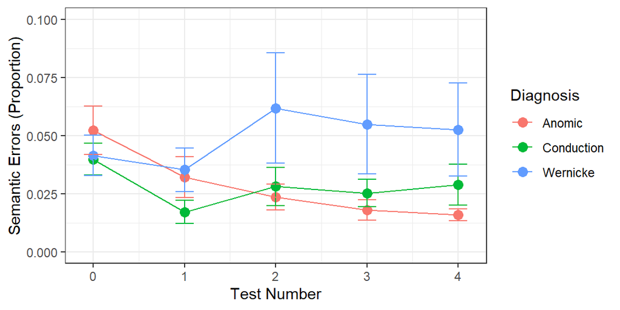

```r
ggplot(NamingRecovery, aes(TestTime, Semantic.error, color=Diagnosis)) +
  stat_summary(fun.y=mean, geom="point", size=3) +
  stat_summary(fun.data=mean_se, geom="errorbar", width=0.2) +
  stat_summary(fun.y=mean, geom="line") +
  labs(x="Test Number", y="Semantic Errors (Proportion)") +
  theme_bw() + expand_limits(y=c(0, 0.1))
```

# Semantic errors: fit a linear model

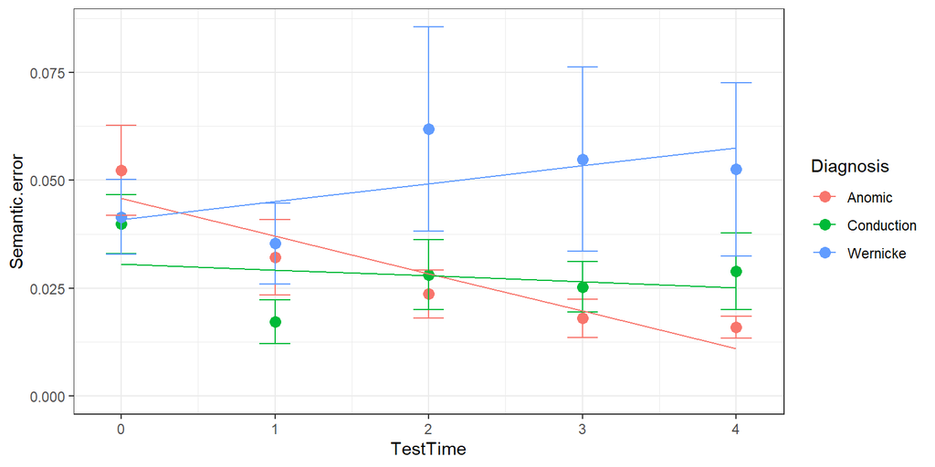

```r
m.sem <- lmer(Semantic.error ~ TestTime*Diagnosis +
                (TestTime | SubjectID), data=NamingRecovery, REML=F)
# plot model fit
ggplot(NamingRecovery, aes(TestTime, Semantic.error, color=Diagnosis)) +
  stat_summary(fun.y=mean, geom="point", size=3) +
  stat_summary(fun.data=mean_se, geom="errorbar", width=0.2) +
  stat_summary(aes(y=fitted(m.sem)), fun.y=mean, geom="line") +
  theme_bw() + expand_limits(y=0)
```

# Semantic errors: p-values

```r
get_pvalues(m.sem)
```

```
##                               Estimate Std..Error t.value  p.normal p.normal.star
## (Intercept)                   0.045767   0.007776  5.8853 3.974e-09           ***
## TestTime                     -0.008685   0.003524 -2.4646 1.372e-02             *
## DiagnosisConduction          -0.015149   0.010039 -1.5090 1.313e-01
## DiagnosisWernicke            -0.004899   0.010287 -0.4762 6.339e-01
## TestTime:DiagnosisConduction  0.007308   0.004549  1.6064 1.082e-01
## TestTime:DiagnosisWernicke    0.012854   0.004662  2.7573 5.829e-03            **
```

Anomic group is the reference group, parameter estimates compare the other groups to it.

- No Group differences at baseline, Anomic and Wernicke groups have different slopes
- But what about the Wernicke - Conduction comparison?

# Brute-force option: make Wernicke the reference group

```r
NamingRecovery$DiagnosisW <- relevel(NamingRecovery$Diagnosis, "Wernicke")
# re-fit the model
m.semW <- lmer(Semantic.error ~ TestTime*DiagnosisW +
                 (TestTime | SubjectID), data=NamingRecovery, REML=F)
get_pvalues(m.semW)
```

```
##                                Estimate Std..Error t.value  p.normal p.normal.star
## (Intercept)                    0.040867   0.006735  6.0683 1.293e-09           ***
## TestTime                       0.004169   0.003052  1.3660 1.719e-01
## DiagnosisWAnomic               0.004899   0.010287  0.4762 6.339e-01
## DiagnosisWConduction          -0.010250   0.009256 -1.1074 2.681e-01
## TestTime:DiagnosisWAnomic     -0.012854   0.004662 -2.7573 5.829e-03            **
## TestTime:DiagnosisWConduction -0.005545   0.004194 -1.3221 1.861e-01
```

- No differences between Conduction and Wernicke groups, other effects stay the same
- This approach works fine, but requires creating new variables and fitting extra models, which can get onerous and error-prone when there are more levels.
- Original model actually has all of the necessary info: can get Wernicke - Conduction comparison by using Anomic group as common baseline.

# Multiple comparisons from a single model

Need to build a *contrast matrix* to define the parameter comparisons w.r.t. model’s parameter estimates

```r
coef(summary(m.sem))
```

```
##                               Estimate Std. Error t value
## (Intercept)                   0.045767   0.007776  5.8853
## TestTime                     -0.008685   0.003524 -2.4646
## DiagnosisConduction          -0.015149   0.010039 -1.5090
## DiagnosisWernicke            -0.004899   0.010287 -0.4762
## TestTime:DiagnosisConduction  0.007308   0.004549  1.6064
## TestTime:DiagnosisWernicke    0.012854   0.004662  2.7573
```

```r
#in contrast matrix, each row is a comparison
#   each element is a weight for parameters from the original model
contrast.matrix <- rbind(
  "Conduction w.r.t. Anomic" = c(0, 0, 1, 0, 0, 0), #3rd param in model
  "Wernicke w.r.t. Anomic" = c(0, 0, 0, 1, 0, 0), #4th param in model
  "Wernicke w.r.t. Conduction" = c(0, 0, -1, 1, 0, 0), #3rd vs. 4th in model: Wernicke-Conduction baseline comparison treating Anomic as common baseline
  "Slope: Conduction w.r.t. Anomic" = c(0, 0, 0, 0, 1, 0), #5th param in model
  "Slope: Wernicke w.r.t. Anomic" = c(0, 0, 0, 0, 0, 1), #6th param in model
  "Slope: Wernicke w.r.t. Conduction" = c(0, 0, 0, 0, -1, 1)) #5th vs. 6th in model: Wernicke-Conduction slope comparison treating Anomic as common baseline
contrast.matrix
```

```
##                                   [,1] [,2] [,3] [,4] [,5] [,6]
## Conduction w.r.t. Anomic             0    0    1    0    0    0
## Wernicke w.r.t. Anomic               0    0    0    1    0    0
## Wernicke w.r.t. Conduction           0    0   -1    1    0    0
## Slope: Conduction w.r.t. Anomic      0    0    0    0    1    0
## Slope: Wernicke w.r.t. Anomic        0    0    0    0    0    1
## Slope: Wernicke w.r.t. Conduction    0    0    0    0   -1    1
```

# Multiple comparisons from a single model

Use the `glht()` function from the `multcomp` package to compute the comparisons defined by the contrast matrix.

```r
library(multcomp)
comps <- glht(m.sem, contrast.matrix)
summary(comps, test = adjusted("none"))
```

```
##
##   Simultaneous Tests for General Linear Hypotheses
##
## Fit: lmer(formula = Semantic.error ~ TestTime * Diagnosis + (TestTime |
##     SubjectID), data = NamingRecovery, REML = F)
##
## Linear Hypotheses:
##                                        Estimate Std. Error z value Pr(>|z|)
## Conduction w.r.t. Anomic == 0          -0.01515    0.01004   -1.51   0.1313
## Wernicke w.r.t. Anomic == 0            -0.00490    0.01029   -0.48   0.6339
## Wernicke w.r.t. Conduction == 0         0.01025    0.00926    1.11   0.2681
## Slope: Conduction w.r.t. Anomic == 0    0.00731    0.00455    1.61   0.1082
## Slope: Wernicke w.r.t. Anomic == 0      0.01285    0.00466    2.76   0.0058 **
## Slope: Wernicke w.r.t. Conduction == 0  0.00555    0.00419    1.32   0.1861
## ---
## Signif. codes:  0 '***' 0.001 '**' 0.01 '*' 0.05 '.' 0.1 ' ' 1
## (Adjusted p values reported -- none method)
```

By default, `glht()` does some kind of correction for multiple comparisons. I don’t know if that correction is appropriate or not. I prefer to not have it do any correction, so it will just return uncorrected normal-approximation p-values, which I can correct for multiple comparisons as needed.

# Exercise 4

Use the full model of the WISQARS suicide data to test all pairwise comparisons between regions.

- Which regions differ from which other regions in terms of baseline suicide rate?
- Which regions differ from which other regions in terms of rate of change of suicide rate?

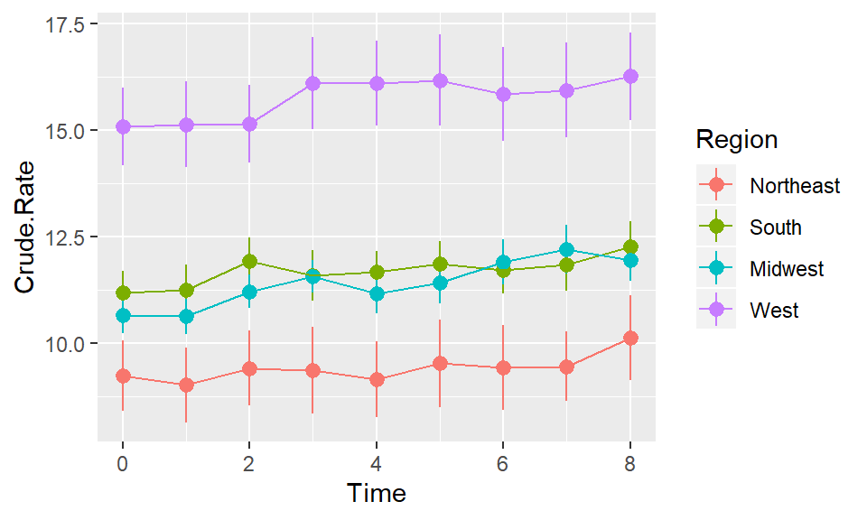

```r
wisqars.suicide$Time <- wisqars.suicide$Year - 1999 # reminder to adjust intercept
ggplot(wisqars.suicide, aes(Time, Crude.Rate, color=Region)) +
  stat_summary(fun.data=mean_se, geom="pointrange") +
  stat_summary(fun.y=mean, geom="line")
```